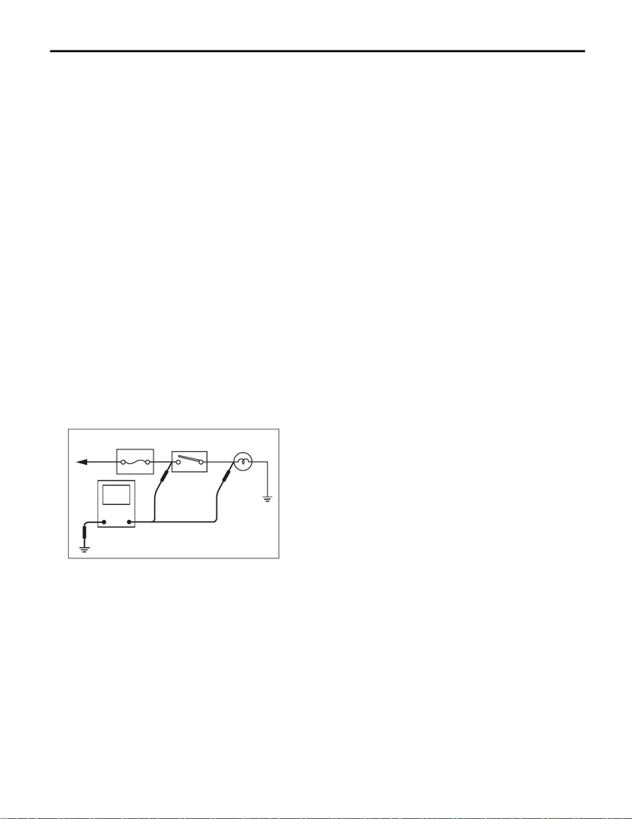

Basic Diagnostic Procedure

WIRING SYSTEM

1. Basic Diagnostic Procedure

A: BASIC PROCEDURES

1. GENERAL DESCRIPTION

The most important purpose of diagnostics is to quickly determine which fault is the root cause of the symp-

tom, to save time and labor.

2. IDENTIFICATION OF TROUBLE CAUSE

1) Using the diagnostics, narrow down the causes.

2) Refer to the wiring diagram and check the system’s circuit. If necessary, use a voltmeter, ohmmeter, etc.

3) Before replacing component parts, check for fuse blowout, open wiring harness on the power supply cir-

cuit and the ground circuit, and poor connectors, switches, relays, etc. If no problem is encountered, check

the component parts.

3. SYSTEM OPERATION CHECK

After inspection and repair, ensure that the system operates properly.

B: BASIC INSPECTION

1. VOLTAGE MEASUREMENT

1) Using a voltmeter, connect the negative lead to a good ground point or negative battery terminal. Connect

the positive lead to the connector or component terminal.

2) Contact the positive lead of the voltmeter on connector (A). The voltmeter will indicate a voltage.

3) Shift the positive lead contacting the connector (A) to the connector (B). The voltmeter will indicate no volt-

age.

4) Turn the switch to ON with the positive lead contacting the connector (B).

The voltmeter will indicate a voltage and, at the same time, the light will illuminate.

5) The circuit is normal. If a problem such as a light failing to illuminate occurs, use the procedures above to

track down the malfunction.

V

(A)

(B)

LightSwitchFuse

To power

supply

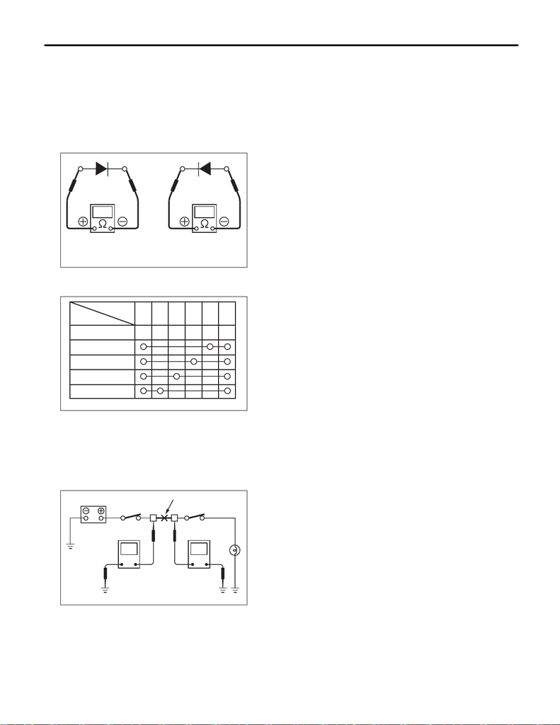

WI-4

Basic Diagnostic Procedure

WIRING SYSTEM

2. CONTINUITY CHECK

1) Disconnect the battery terminal or connector so there is no voltage between the check points.

Contact the leads of an ohmmeter between the check points, and check that there is continuity.

2) When checking the diode continuity using an ohmmeter, allow the positive lead to contact the diode pos-

itive side and the negative lead to the negative side. At this time, there must be continuity. Also, when con-

tacting the leads in reverse, there should be no continuity.

NOTE:

Some testers have reverse polarity, therefore, refer to the instruction manual of the tester.

3) When checking switch continuity using an ohmmeter, perform the check while the switch operates. For ex-

ample, when a switch position is at 3, continuity exists among terminals 1, 3 and 6, as shown below.

3. HOW TO IDENTIFY AN OPEN CIRCUIT

1) With voltmeter:

An open circuit is determined by measuring the voltage between respective connectors and ground using a

voltmeter, starting with the connector closest to the power supply. The power supply must be turned ON so

that current flows in the circuit. If voltage is not present between a particular connector and ground, the circuit

between that connector and the previously checked point is open.

Non continuityContinuity

OFF

WI-36092

1

2

3

4

123456

Switch Position

Terminal

WI-36093

0V12V

V

V

Open circuit

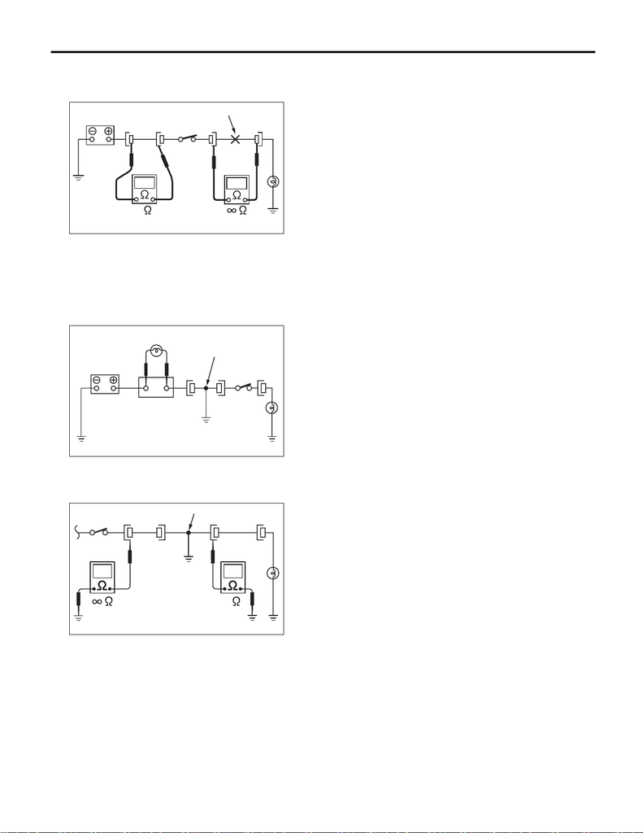

WI-5

Basic Diagnostic Procedure

WIRING SYSTEM

2) With ohmmeter:

Disconnect all connectors affected, and check continuity in the harness between adjacent connectors. When

the ohmmeter indicates “infinite”, the harness is open.

4. HOW TO DETERMINE A SHORT CIRCUIT

1) With test light:

Connect a test light (rated at approx. 3 watts) in place of the blown fuse and allow current to flow through the

the power supply. If the test light goes out when a connector is disconnected, the harness between that con-

nector and the next connector (farther from the power supply) is shorted.

2) With ohmmeter:

Disconnect all affected connectors, and check continuity between each connector and ground. When the

ohmmeter indicates continuity between a particular connector and a ground, that connector is shorted.

0

Open circuit

WI-36095

Shorted wiring

Fuse holder

Test light

WI-36096

0

Shorted wiring

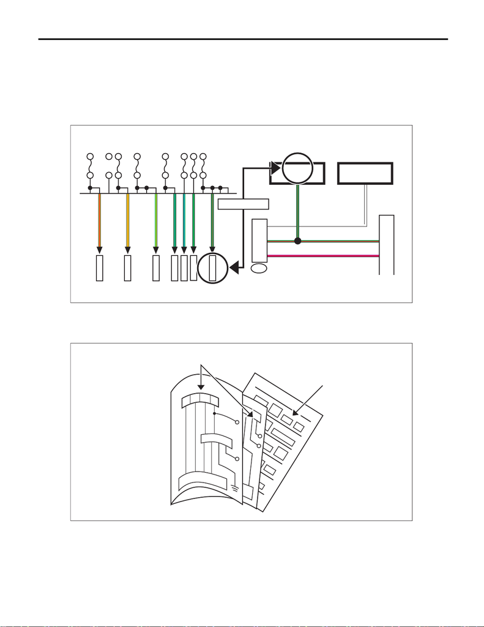

WI-6

Basic Diagnostic Procedure

WIRING SYSTEM

C: HOW TO READ WIRING DIAGRAMS

1. POWER SUPPLY CIRCUIT

Circuits are described to indicate the power supply in the wiring diagram of each system. “MB-5”, “MB-6”,

etc., which are used as power-supply symbols throughout the text, correspond with those shown in the “DC

POWER SUPPLY CIRCUIT” in the wiring diagram of each system. Accordingly, using the DC power supply

circuit and the wiring diagram of each system permits service personnel to understand the entire electrical ar-

rangement of the system.

2. WIRING DIAGRAM OF EACH SYSTEM

1. Structure

After the wiring diagram of each system, a list of connectors used in the system is described.

WI-36070

C7

D7Y/R

G/Y

G

C8

G/L

D9

C16G/L

G/R

G/R

G/R G/R

C24

Y/R

A20

FB 29

FB 32

FB 34

FB 35

FB 38

FB 26

FB 36

W

3

V/R

1

8

W

16

V/R

7

-

-

-

-

-

-

-

IMPACT

SENSOR

DATA LINK CONNECTOR

MB-27

M/B FUSE NO. 13

(B)

FB-38

F/B FUSE NO. 4

(IG)

Corresponding to

WIRING DIAGRAM OF EACH SYSTEMPOWER SUPPLY CIRCUIT

WI-36071

Wiring diagram of each system

List of connectors

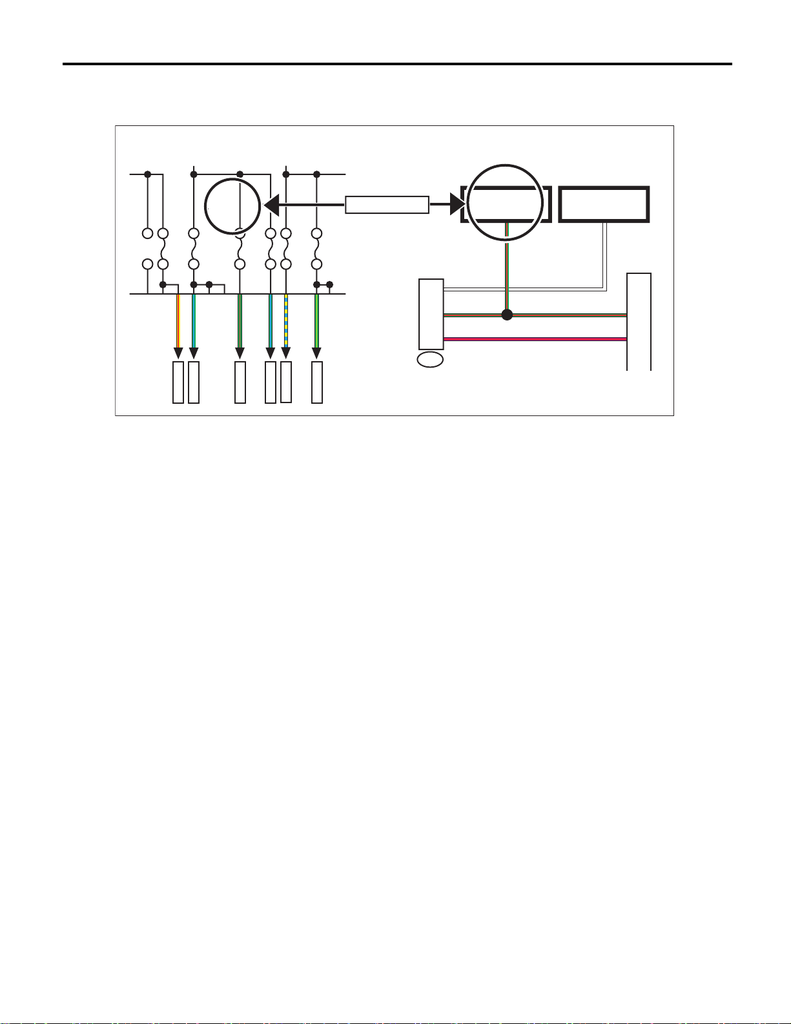

WI-7

Basic Diagnostic Procedure

WIRING SYSTEM

2. Fuse No. & rating

The “Fuse No. & rating” is the same description as that in the DC power supply circuit, and corresponds with

that used in the vehicle.

1

WI-36072

G/R

G/R G/R

W

3

V/R

1

8

W16

V/R7

FB 29

FB 32

FB 34

FB 35

FB 38

D7Y/R

G/Y

C8

G/L

D9

C16G/L

G/R

C24

FB 36

A20

-

-

-

-

-

-

IMPACT

SENSOR

DATA LINK CONNECTOR

WIRING DIAGRAM OF EACH SYSTEMPOWER SUPPLY CIRCUIT

Corresponding to

No. 30

No. 31 7.5A

No. 12 15A

No. 11 7.5A

No. 4 10A

No. 18 10A

No. 5 10A

MB-27

M/B FUSE NO. 13

(B)

FB-38

F/B FUSE NO. 4

(IG)

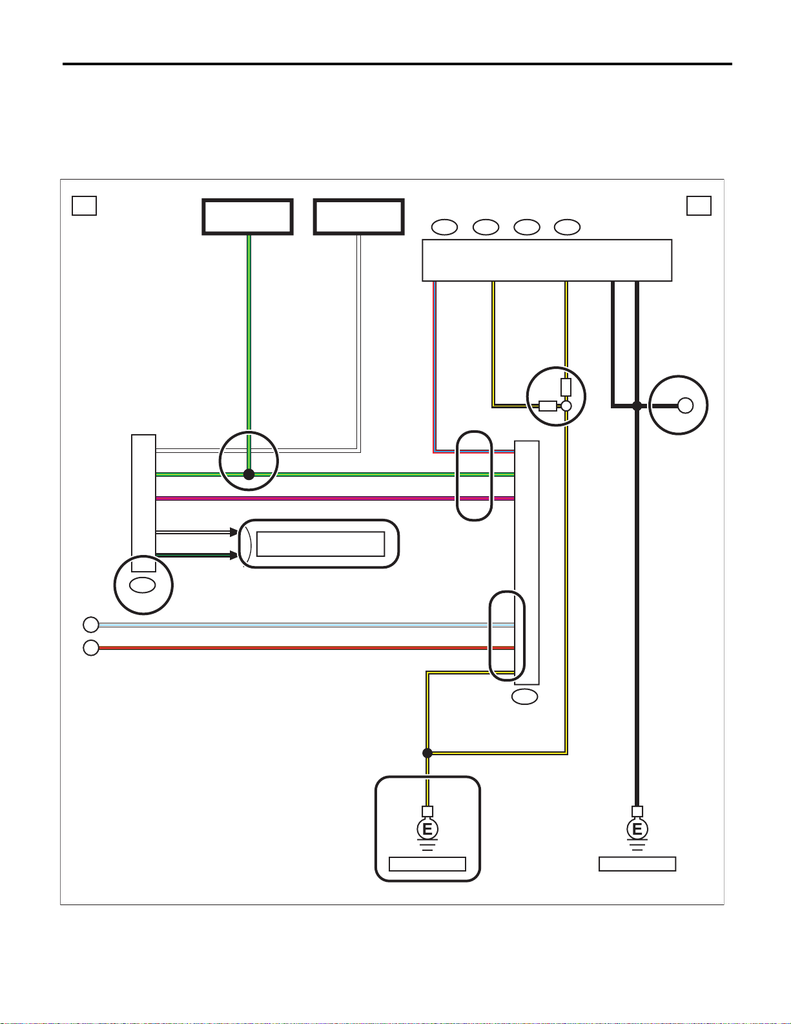

WI-8

Basic Diagnostic Procedure

WIRING SYSTEM

3. Wiring diagram of each system

To help figure out the route from the DC power supply circuit, wiring diagrams are classified and described

in each system.

NOTE:

This manual includes harness information. Information of parts that are not routed via harness and adapter

code is described as a reference. If no information is described in this manual, refer to each section.

B40

AT

MT

WI-36073

(A)

(D)

(C)

(G)

(F)

(H)

(B)

(E)

2

W

G/Y

3

V/R

4

W/L

8

BR/R

7

B/Y

1

G/Y

R/L

B/G

4

B/W

5

G/Y

8

W

16

V/R

7

B567

i171

A

B280

B B281 C D

i84

B

C

A

A11R/L

A1B/Y

B31B/Y

D29B

C1B

B/Y

B/Y

B

::::

REF. TO GND [g]REF. TO GND [c]

IMPACT

SENSOR

BODY INTEGRATED UNIT

REF. TO ENGINE ELECTRICAL

SYSTEM [1f] [2f]

DATA LINK

CONNECTOR

MB-27

M/B FUSE NO. 13

(B)

FB-38

F/B FUSE NO. 4

(IG)

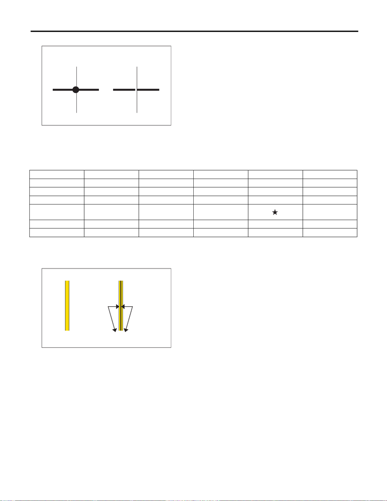

WI-9

Basic Diagnostic Procedure

WIRING SYSTEM

• (A): Wire connection and crossing in a circuit

• (B): Classification by specifications

If a circuit differs from another circuit according to vehicle specifications, the specification difference is in-

dicated with abbreviations.

• (C): Color code

Indicates the color of harness and connector housing.

(Color code of harness)

Single color is indicated with a color code, and double colors are indicated with “standard color / marking

color”.

WI-36074

W

BB

W

Crossed circuit

(non-identical circuit)

Connected circuit

(identical circuit)

Color code Color Color code Color Color code Color

B Black S Shield line GR Gray

G Green V Violet LG Light green

LBlueWWhiteSBSky blue

O Orange Y Yellow

White or natural

color

PPinkBEBeige

R Red BR Brown

WI-36075

Y Y/B

(Black)(Yellow)

Marking colorReference color

Two-colorSingle color

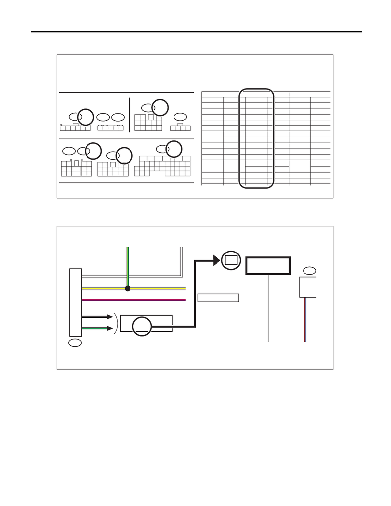

WI-10

Basic Diagnostic Procedure

WIRING SYSTEM

(Color code of connector housing)

Used in the connector list and the locations.

• (D): Connection to another system in the same circuit

Indicates the connecting to with alphanumeric characters, which correspond to the descriptions shown on

the upper section of each page.

• (E): Connections in the system

Indicates with alphabetic characters, which correspond to the same alphabetic characters shown in the

following pages.

31 32 33 34 35

1

23

4

56

1211 1413 1615

6

10

87

5

9

2134

3

421

5

98

27

7

151413121110 16

63451

2

3

421

56

7

13 1411

9

10

8

i84

2322 24 25 26

17

3

421

13

11

12

9

10

78564

i54

12

19

18

21

20

312

B479

i53

i102

B

B

B

G

GR

GR

GR

GR

GR

GR

GR

GR

GR

GR

B3

B6

B8

B10

B11

B12

B14

B15

B16

B19

B21

B128

5

T4

T3

T3

T5

E2

T9

5

4

4

6

8

1

20

12

54

2

2

2

60

A

C

D47

D34

B350

B491

(GR)

(GR)

(GR)

(G)

(B)

:

:

.

B-4

B-4

B-4

B-3

B-3

B-3

B-3

B-3

B-3

B-3

B-3

B-3

B-3

B-2

LIST OF CONNECTORS

Starter mot

Mass air flo

Area No.

No. Pole

Connector

LOCATION

Transmissio

Engine wirin

Brake fluid

Transmissio

Transmissio

Transmissio

Pressure sw

Front wipere

Front ABS

Front ABS

LOCATION

Rear washe

Rear washe

Color

Bulkhead Wiring Harness (In Engine

B40

1f

B/G4

B/W5

G/Y

8

W16

V/R

7

W

A

B280

A11R/L

WI-36077

:

DATA LINK

CONNECTOR

REF. TO KEYLESS ENTRY

SYSTEM [1f]

Corresponding to

Keyless entry system

MB-27

M/B FUSE NO. 13

(B)

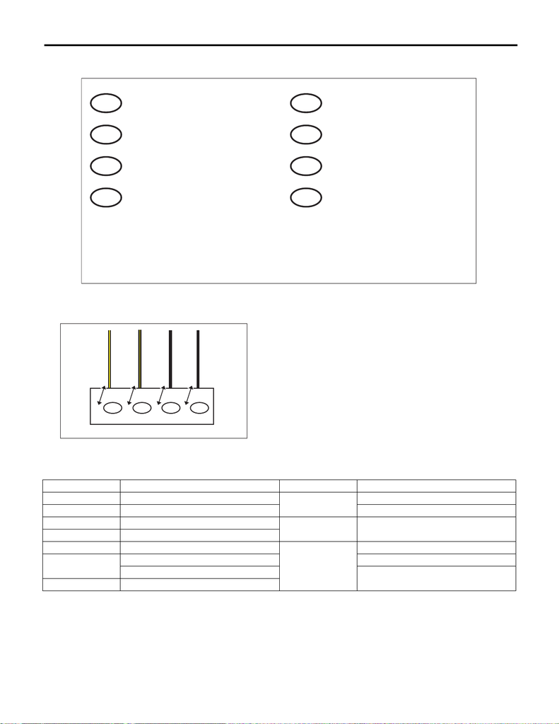

WI-11

Basic Diagnostic Procedure

WIRING SYSTEM

• (F): Ground

The ground points shown in the ground circuit refer to the following, which correspond to the locations.

• (G): Terminal No.

Indicates the terminal number of the connector to be connected. If several connectors are connected to

a component, they are identified with alphabetic characters.

• (H): Connector No.

The first alphabetic characters of the connector number correspond with the following symbols that indi-

cate harnesses or systems.

GR

GV

GP

GPT

WI-36078

GAP

GAB

GB

GE

VDC GROUND

PTC HEATER GROUND

Not all grounding points are used in this manual.

Note:

AIR PUMP GROUND

AUDIO GROUND

ENGINE GROUND

BODY GROUND

AIRBAG GROUND

ELECTRIC POWER

STEERING GROUND

WI-36079

A:

B280

B:

B281 C: D:

i84

A1

B/Y

D29

B

C1

B

B31

B/Y

Symbol Harness/cord Symbol Harness/cord

AB Airbag wiring harness

F

Front wiring harness

AD Adapter cord Generator cord

AT/T Transmission cord

i

Instrument panel

Wiring harness

B Bulkhead wiring harness

D Door cord / Rear gate code

R

Rear wiring harness

E

Engine wiring harness Fuel cord / Roof cord

Oxygen sensor cord

Rear gate cord /

Trunk lid cord

ST Steering cord

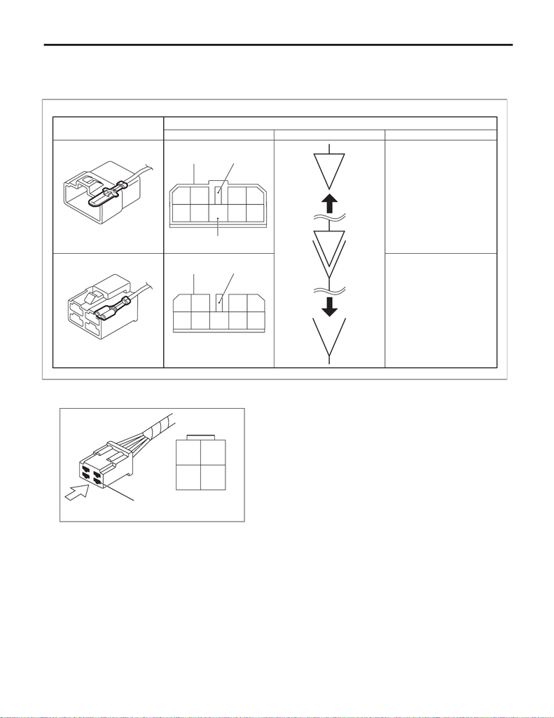

WI-12

Basic Diagnostic Procedure

WIRING SYSTEM

4. Connector

The following shows the connector shape, lock position, connection and terminal number that are used in this

manual.

For connector shape, refer to the list of connectors.

• The sketch of the connector and the terminal number are indicated in a disconnected state which is

viewed from the terminal side.

• The sketch of the connector described in the list of connectors usually indicates a female connector.

43

2

1

98

7

65

12

3

4

56

7

8

9

Female connector

Male connector

Connector shown in wiring diagram

Terminal arrangement orderWiring diagram symbolConnector sketch

Double

frames

Single

frame

Indicates the number of poles.

Indicates a

lock is included.

Indicates a

lock is included.

Numbered in order from

upper right to lower left.

Numbered in order from

upper left to lower right.

Connector used in vehicle

WI-36081

4

4

2

3

1

Viewed from this direction

Connector sketch

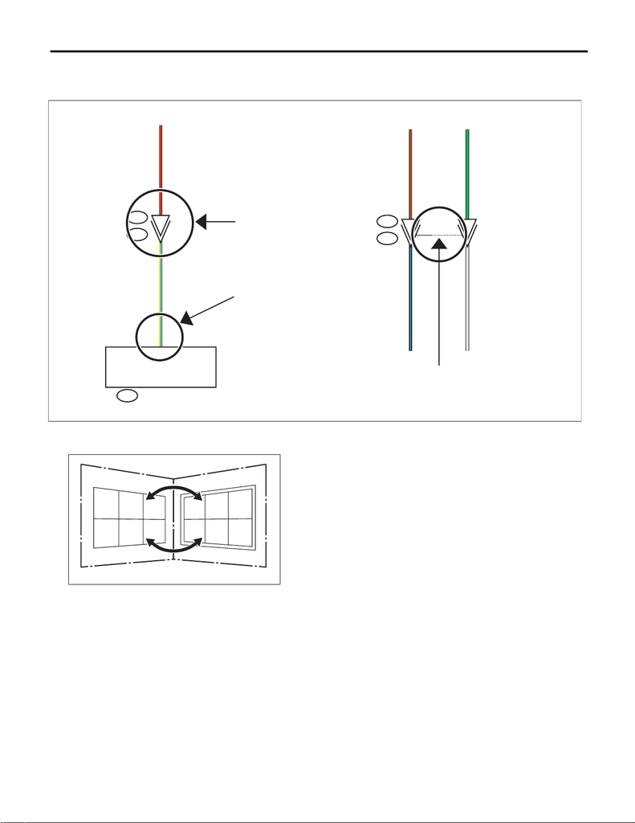

WI-13

Basic Diagnostic Procedure

WIRING SYSTEM

• The connector used in the wiring diagram of the system indicates only the intermediate connection,

therefore, no parts, J/Cs and grounds are described. In addition, if the different circuits are connected with

the same connector, a dot line is used to indicate that these are the same.

• When connecting the connector, the terminals with the same number are jointed. When the connector

is disconnected, the terminal location is symmetrical.

10

3

i68

Y/LD7

B23

BR/R

i171

D

B68

GR/W

B/L

ST1

G

BR

WI-36082

Connected to component

Identical connector

BODY INTEGRATED UNIT

Dashed line

In-line connection

WI-36083

1

2

3

4

5

6

1

2

3

4

5

6

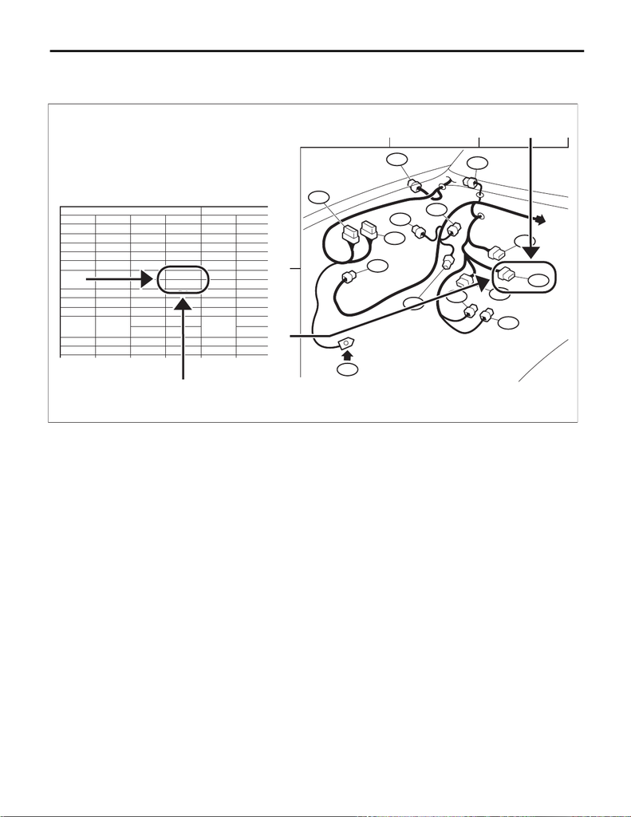

WI-14

Basic Diagnostic Procedure

WIRING SYSTEM

3. LOCATION

In this manual, the location is classified in each harness, and the connector location is indicated using coor-

dinates.

A

B

B3

B16

B6

B8

B11

B12

B25

B24

B567

B305

B310

B565

GV

B22

B

B

B

G

GR

GR

GR

GR

GR

GR

GR

GR

GR

GR

B3

B6

B8

B10

B11

B12

B14

B15

B16

B19

B21

B128

5

T4

T3

T3

T5

E2

T9

5

4

4

6

8

1

20

12

54

2

2

2

60

LH

WI-36084

.

B-4

B-4

B-4

B-3

B-3

B-3

B-3

B-3

B-3

B-3

B-3

B-3

B-3

B-2

A:

CONNECTOR LOCATION VIEW

Letters in "Area" corresponds with connector location view.

CONNECTOR LOCATION CHART

LOCATION

Area No.

No. Pole

Connector

Color

Starter mot

Mass air flo

Transmissio

Engine wirin

Brake fluid

Transmissio

Transmissio

Transmissio

Pressure sw

Front wipere

Front ABS

Front ABS

Rear washe

Rear washe

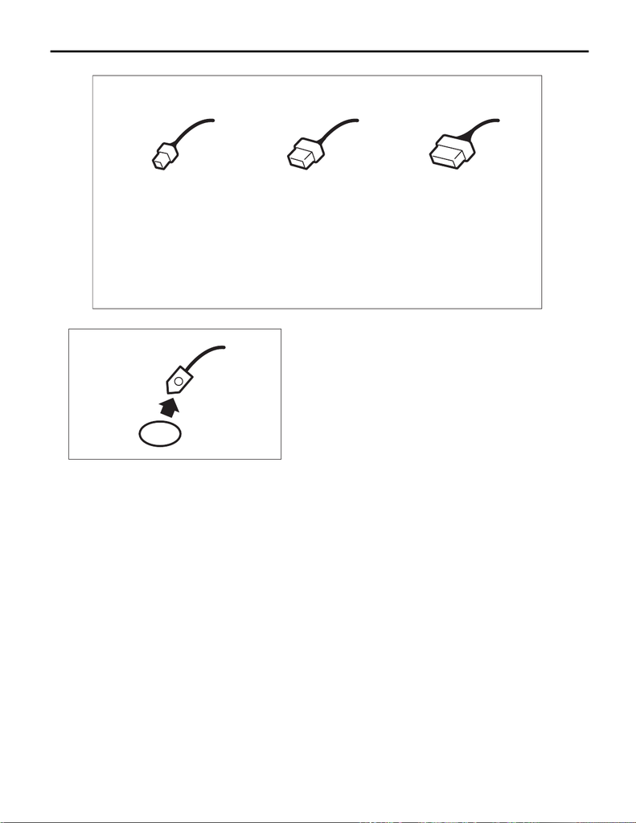

WI-15

Basic Diagnostic Procedure

WIRING SYSTEM

• The following connector symbols are used to easily identify the connectors.

• The ground point is indicated as follows.

-36085

Pole: 21 or morePole: 9 to 20Pole: 1 to 8

(Large)(Medium)(Small)

WI-36086

GR

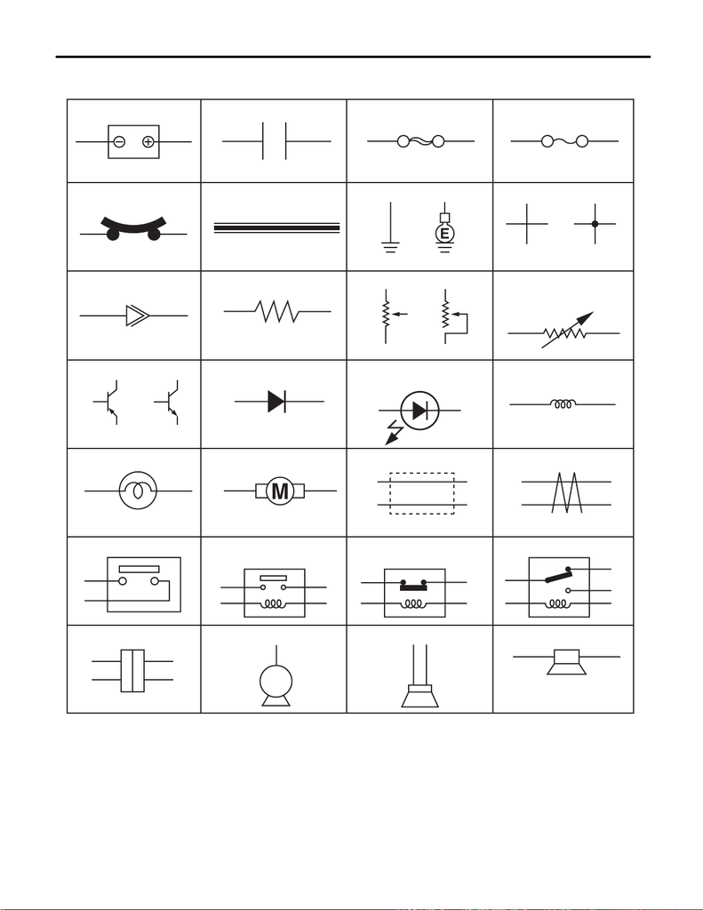

WI-16

Basic Diagnostic Procedure

WIRING SYSTEM

4. SYMBOLS IN WIRING DIAGRAMS

NPNPNP

VARIABLE RESISTANCE

Terminal 3 Terminal 2

VARIABLE RESISTANCE

(SENSOR)

RESISTANCE

FemaleMale

CONNECTOR

SPEAKERROLL CONNECTOR BUZZERHORN

CIRCUIT BREAKER BUS BAR

Connected

circuit

Crossed

circuit

WIRING HARNESSGROUND

TRANSISTOR COIL/SOLENOIDLIGHT EMITTING

DIODE

DIODE

CONDENSERBATTERY SLOW BLOW FUSE FUSE

MOTOR/PUMPLIGHTING SHIELD TWISTED PAIR

(NORMAL CLOSE)

RELAY SPDT RELAY

(NORMAL OPEN)

RELAYSWITCH

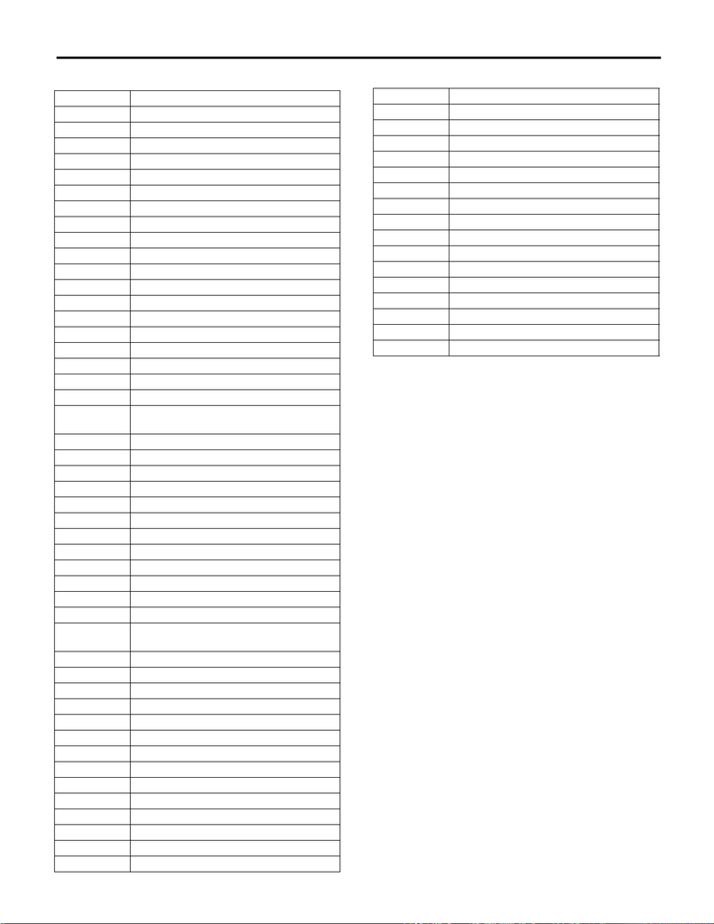

WI-17

Basic Diagnostic Procedure

WIRING SYSTEM

5. ABBREVIATIONS IN THIS MANUAL

Abbr. Full name

ABS Anti-lock Brake System

ACC Accessory

A/C Air Conditioner

ASSY Assembly

A/F Air/Fuel (air fuel ratio sensor)

ATF Automatic Transmission Fluid

AUX Auxiliary Audio Input Terminal

AWD All Wheel Drive

B, BAT Battery

CAN Controller Area Network

CL Close

CM Control Module

CVT Continuously Variable Transmission

D Drive range or Down

DC/DC Direct Current / Direct Current (converter)

DCCD Driver's Control Center Differential

DN Down

EGround

ECM Engine Control Module

EEPROM

Electrically Erasable Programmable Read-

Only Memory

EGR Exhaust Gas Recirculation

ELCM Evaporative Leak Check Module

FFront

F/B Fuse & Relay Box

FL Front Left

FR Front Right

G Gravity (G sensor)

H/L Headlight

HI High

I/F Interface

IG Ignition

INT Intermittent

ISO

International Organization for Standardiza-

tion

J/C Joint Connector

LCD Liquid Crystal Display

L, LH Left Hand

LO Low

LWR Lower

MMotor

M/B Main Fuse Box

MFD Multi Function Display

MIST Wiper for mist

MT Manual Transmission

N Neutral Range

OP Optional Parts or Open

P Parking or Parking range

PASS Passing

R Reverse Range

RES Reset

R, RH Rear or Right Hand

RL Rear Left

RR Rear Right

SBF Slow Blow Fuse

SI-DRIVE SUBARU Intelligent Drive

ST Starter

SW Switch

TCM Transmission Control Module

TFT Thin Film Transistor

TPMS Tire Pressure Monitor System

UP Up

UPR Upper

VDC Vehicle Dynamics Control

WASH Washer

Abbr. Full name